# Assignment 6 - ALY2100 CRN SEC 02 Fall 2023 CPS

Student: Margarita Kholostova

Instructor: Vladimir Shapiro

Date: October 12, 2023

## Introduction

Grade evaluation has always been an integral aspect of the educational system. Grades not only measure a student's understanding and grasp of a subject but also play a pivotal role in gauging one's strengths and areas of improvement. This assignment introduces the concept of a grade calculator, an automated system that simplifies the grading process by converting numeric grades into corresponding letter grades. By delving deep into this topic, we aim to understand the role of data structures, specifically dictionaries, in Python. Dictionaries, in Python, serve as a valuable tool to associate keys (in this case, numeric grade ranges) with their corresponding values (the respective letter grades) (OpenAI, 2023).

## Analysis

### Assignment: Implement a Grade Calculator

Objective: This assignment aims to create a Python program that takes numeric grades as input and calculates the corresponding letter grade for each grade entered.

Instructions:

1. Create a dictionary that maps numeric grade ranges to their corresponding letter grades. Use the following ranges and letter grades:
   - 90 and above: 'A'
   - 80 to 89: 'B'
   - 70 to 79: 'C'
   - 60 to 69: 'D'
   - Below 60: 'F'
2. Write a Python program that repeatedly takes input from the user until they enter a negative value. Use the dictionary to determine the corresponding letter grade and print the result for each positive numeric grade entered.
3. If the input grade is outside the range of 0 to 100, print an error message indicating that the input is invalid.
4. After processing all the valid input grades, print a message displaying the total number of grades entered, the number of grades falling into each letter grade category, and the percentage of each letter grade category relative to the total number of grades entered.

Example Output:

```
Grade Calculator

Enter a numeric grade (negative value to quit): 87
Grade: 87 - Letter Grade: B

Enter a numeric grade (negative value to quit): 92
Grade: 92 - Letter Grade: A

Enter a numeric grade (negative value to quit): 78
Grade: 78 - Letter Grade: C

Enter a numeric grade (negative value to quit): 55
Grade: 55 - Letter Grade: F

Enter a numeric grade (negative value to quit): 102
Invalid input! Please enter a valid numeric grade (0-100).

Enter a numeric grade (negative value to quit): -1

Grade Summary:
Total grades entered: 4
Number of A's: 1 (25%)
Number of B's: 1 (25%)
Number of C's: 1 (25%)
Number of F's: 1 (25%)
```

Note: You can add more error handling or additional features to the program if you like. The key is to use a dictionary to map numeric grades to letter grades and provide relevant output based on the user input

Note: You can add more error handling or additional features to the program if you like. The key is to use a dictionary to map numeric grades to letter grades and provide relevant output based on the user input.

Ensure you use all features learned so far, including loops, creating your own function. At this point, explaining your solution is a must on top of comments in your code and try/exception and validating user input.

Build a flow chart; use file input/output features. YOU MUST VALIDATE ALL USER INPUT AND ALWAYS GIVE FRIENDLY ERROR MESSAGES. Make sure to have a loop until the user enters a negative grade.

Make sure to save each grade entered or result printed to a Word or spreadsheet file and the final summary. Save the file so I can access it once I run your program.

### Flowchart

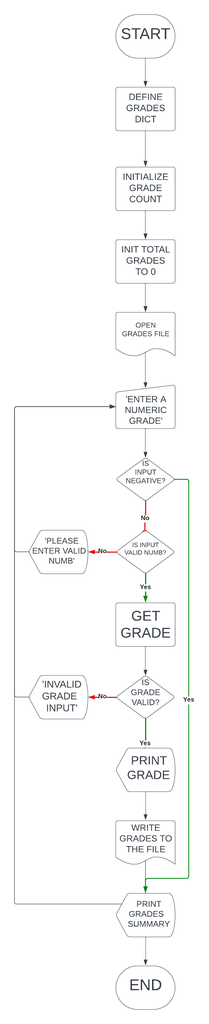

Figure 1. Flowchart for solution

```python
from pprint import pprint
```

```python
# Explanation:
# This program is designed to take numeric grades as input and convert them to corresponding letter grades.
# The program will repeatedly take inputs until a negative value is entered.
# For each valid grade entered, it will output the letter grade and save this to a text file.
# The program will also save a final summary to the same file.

grades_dictionary = {'A': (90, 100), 'B': (80, 89), 'C': (70, 79), 'D': (60, 69), 'F': (0, 59)}

def get_grade(user_input):
    """Function to map numeric grade to its corresponding letter grade."""
    for grade, (min_score, max_score) in grades_dictionary.items():
        if min_score <= user_input <= max_score:
            return grade
    return None

grade_counts = {'A': 0, 'B': 0, 'C': 0, 'D': 0, 'F': 0, 'Invalid': 0}
total_grades = 0

# open a text file to save grades and summary.
with open("grades_summary.txt", "w") as file:

    while True:

        try:
            user_input = int(input("Enter a numeric grade (negative value to quit): "))

            # exit the loop for any negative value.
            if user_input < 0:
                break

            grade = get_grade(user_input)
            if grade:
                grade_counts[grade] += 1
                total_grades += 1
                message = f"Grade: {user_input} - Letter Grade: {grade}\n"
                print(message)
                file.write(message)
            else:
                error_message = "Error: Invalid grade input. Please enter a grade between 0 and 100.\n"
                print(error_message)
                file.write(error_message)
                grade_counts['Invalid'] += 1

        # for any input that is not a number.
        except ValueError:
            print("Error: Please enter a valid number.")

    file.write("\nGrade summary:\n")
    file.write(f"Total grades entered: {total_grades}\n")
    for grade, count in grade_counts.items():
        if grade != 'Invalid':
            message = f"Number of {grade}'s: {count} ({count/total_grades*100:.1f}%)\n"
            print(message)
            file.write(message)
    #only for input that is more then 100, when NONE is returned from get_grade funct
    if grade_counts['Invalid'] > 0:
        error_message = f"Number of invalid grades entered: {grade_counts['Invalid']}\n"
        print(error_message)
        file.write(error_message)
```

```
Enter a numeric grade (negative value to quit): a
Error: Please enter a valid number.
Enter a numeric grade (negative value to quit): /
Error: Please enter a valid number.
Enter a numeric grade (negative value to quit): 101
Error: Invalid grade input. Please enter a grade between 0 and 100.

Enter a numeric grade (negative value to quit): 0.5
Error: Please enter a valid number.
Enter a numeric grade (negative value to quit): 12
Grade: 12 - Letter Grade: F

Enter a numeric grade (negative value to quit): 34
Grade: 34 - Letter Grade: F

Enter a numeric grade (negative value to quit): 56
Grade: 56 - Letter Grade: F

Enter a numeric grade (negative value to quit): 78
Grade: 78 - Letter Grade: C

Enter a numeric grade (negative value to quit): 90
Grade: 90 - Letter Grade: A

Enter a numeric grade (negative value to quit): 90
Grade: 90 - Letter Grade: A

Enter a numeric grade (negative value to quit): 67
Grade: 67 - Letter Grade: D

Enter a numeric grade (negative value to quit): 88
Grade: 88 - Letter Grade: B

Enter a numeric grade (negative value to quit): 89
Grade: 89 - Letter Grade: B

Enter a numeric grade (negative value to quit): 60
Grade: 60 - Letter Grade: D

Enter a numeric grade (negative value to quit): 100
Grade: 100 - Letter Grade: A

Enter a numeric grade (negative value to quit): 50
Grade: 50 - Letter Grade: F

Enter a numeric grade (negative value to quit): 77
Grade: 77 - Letter Grade: C

Enter a numeric grade (negative value to quit): -1
Number of A's: 3 (23.1%)

Number of B's: 2 (15.4%)

Number of C's: 2 (15.4%)

Number of D's: 2 (15.4%)

Number of F's: 4 (30.8%)

Number of invalid grades entered: 1
```

# Conclusions

For this assignment, we have embarked on a journey to grasp the practical application of Python dictionaries in real-world scenarios. The grade calculator serves as a testament to the efficiency and utility of these data structures in automating and simplifying tasks. We learned the importance of user interaction, where we prompt users for their input and provide meaningful feedback. Furthermore, the assignment emphasized the need for effective error handling, ensuring the program can address out-of-range inputs. From a broader perspective, such grade calculators could play a pivotal role in educational institutions, reducing manual effort and potential human errors in the grading process. This hands-on experience reaffirms the versatility of Python as a programming language and its applications in various fields (OpenAI, 2023).

# References

1. GeeksforGeeks. (2023, June 26). String formatting in Python. GeeksforGeeks. https://www.geeksforgeeks.org/string-formatting-in-python/
2. Guttag, J. V. (2021). Introduction to computation and programming using python, third edition: With application to computational modeling and Understanding Data. MIT Press.
3. Kalb, I. (2018). Learn to program with python 3: A step-by-step guide to programming. Apress.
4. OpenAI. (n.d.). Chatgpt. ChatGPT. https://openai.com/chatgpt
5. Python dictionary. Programiz. (n.d.). https://www.programiz.com/python-programming/dictionary